# Linear Models- continued

# Overfitting

When a regression model captures noise, it means the model is trying to explain these random deviations as if they were part of the underlying pattern. This typically happens in the following situations:

- High Degree Polynomial Regression: Using a very high degree polynomial to fit data that has an underlying linear or low-degree polynomial relationship. The model bends and twists to fit every single data point, including the noisy ones.
- Too Many Features: Including too many predictors in the model, some of which may not have a real association with the outcome but appear to due to random chance in the sample data.
- Insufficient Data: Having too few data points relative to the complexity of the model, leading the model to fit the peculiarities of the small sample rather than the true relationship.

**Consequences**

- The main consequence of capturing noise is poor model generalization. While the model may show excellent performance on the training data, it performs poorly on new, unseen data because it has learned to fit the noise rather than the true signal.

-Visual Representation In a visual sense, capturing noise means the fitted regression line (or curve) will be very wiggly and closely follow each data point, as opposed to a smoother line that captures the general trend.

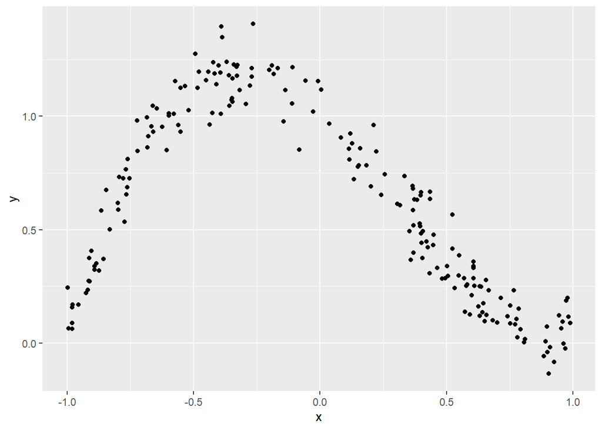

```r
true_relationship <- function(x,sigma=0.1){
  1-x-x^2+x^3+rnorm(length(x),sd=sigma)
}

x <- runif(200,min=-1,max=1)

set.seed(1)
y <- true_relationship(x)

data_all <- data.frame(y,x)

ggplot(data=data_all,
       aes(x=x,y=y)) +
  geom_point()
```

This is all the data, but we typically only have access to a subset of the data.

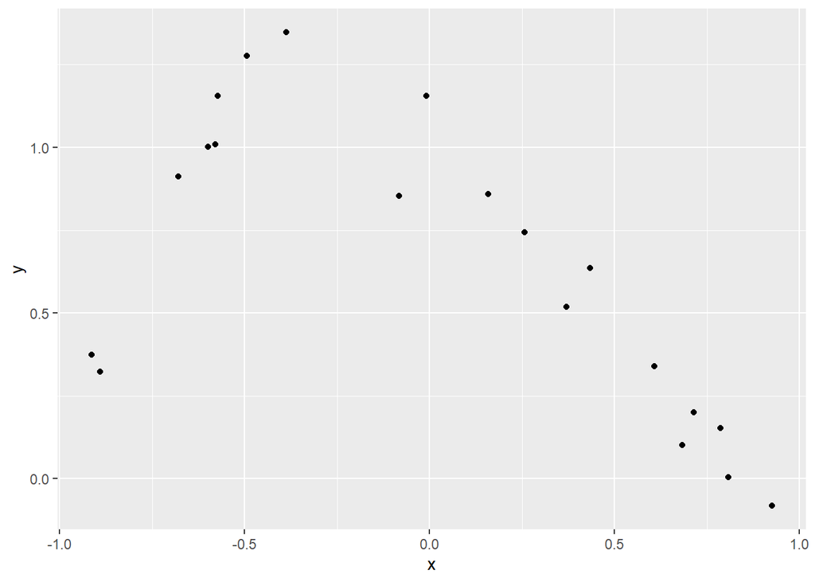

```r
set.seed(1)

observations <- sample(1:dim(data_all)[1],20)

x <- data_all$x[observations]
y <- data_all$y[observations]

data_a <- data.frame(y,x)

ggplot(data=data_a,
       aes(x=x,y=y)) +
  geom_point()
```

What if we fit a linear regression to this data?

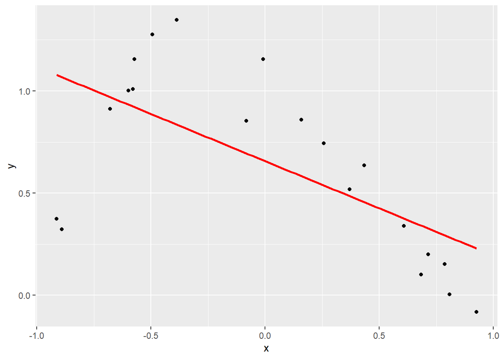

```r
lm_a_1 <- lm(y~x,data=data_a)

data_a$y_1 <- predict(lm_a_1,data_a)

ggplot(data=data_a,
       aes(x=x,y=y)) +
  geom_point() +
  geom_smooth(method="lm",
              formula=y~x,
              col="red",
              se=F)
```

```r
error_a <- rep(NA,19)
error_a[1] <- sum((data_a$y-data_a$y_1)^2)/20
error_a[1]
```

```
[1] 0.1114031
```

What if we fit a quadratic polynomial to this data?

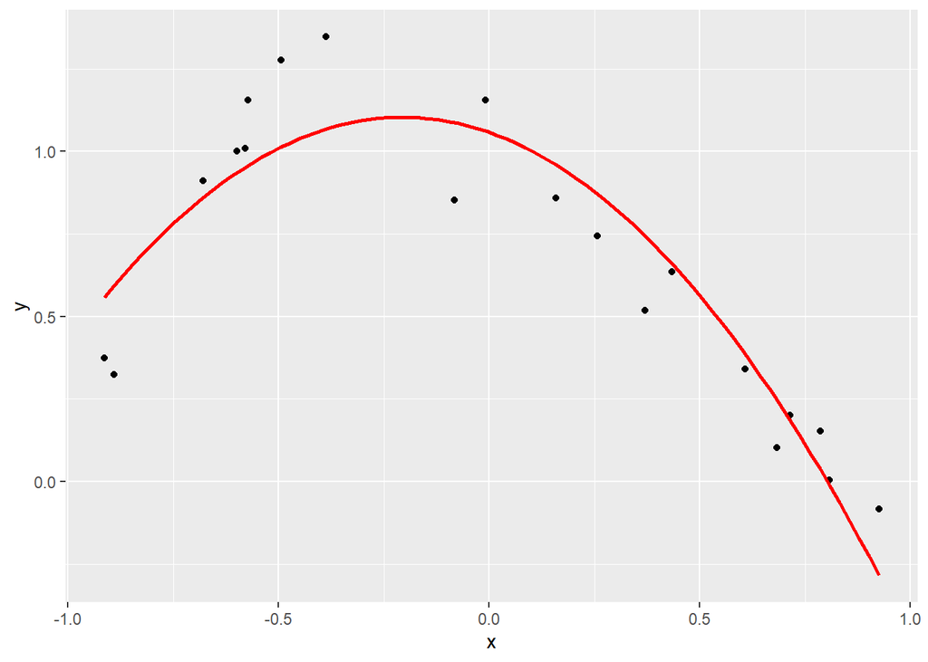

```r
lm_a_2 <- lm(y~poly(x,2),data=data_a)

data_a$y_2 <- predict(lm_a_2,newdata=data_a)

ggplot(data=data_a,
       aes(x=x,y=y)) +
  geom_point() +
  geom_smooth(method="lm",
              formula=y~poly(x,2),
              col="red",
              se=F)
```

```r
error_a[2] <- sum((data_a$y-data_a$y_2)^2)/20
error_a[2]
```

```
[1] 0.02615057
```

What if we fit a 10th order polynomial to this data?

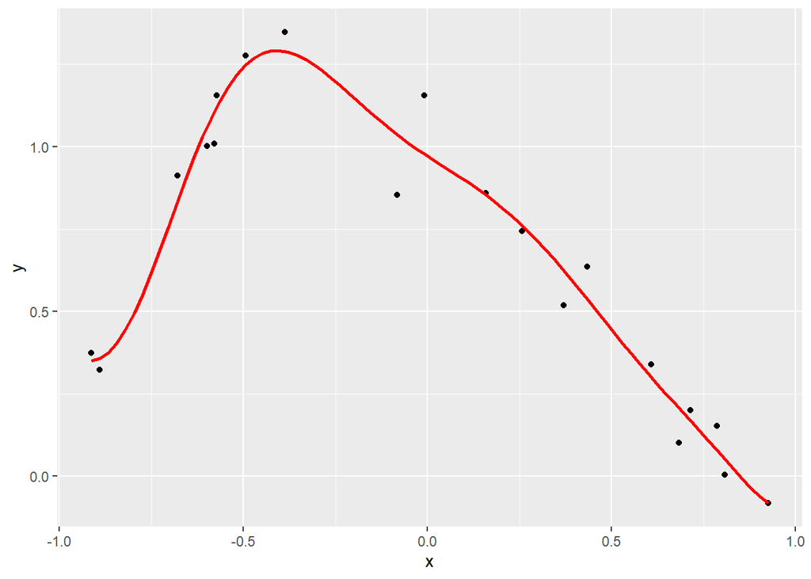

```r
lm_a_10 <- lm(y~poly(x,10),data=data_a)

data_a$y_10 <- predict(lm_a_10,newdata=data_a)

ggplot(data=data_a,
       aes(x=x,y=y)) +
  geom_point() +
  geom_smooth(method="lm",
              formula=y~poly(x,10),
              col="red",
              se=F)
```

```r
error_a[10] <- sum((data_a$y-data_a$y_10)^2)/20
error_a[10]
```

```
[1] 0.006675287
```

How do the same models perform at making predictions for all of the data?

```r
data_all$y_1 <- predict(lm_a_1,newdata=data_all)
data_all$y_2 <- predict(lm_a_2,newdata=data_all)
data_all$y_10 <- predict(lm_a_10,newdata=data_all)

error_all <- rep(NA,20)

error_all[1] <- sum((data_all$y-data_all$y_1)^2)/20
error_all[2] <- sum((data_all$y-data_all$y_2)^2)/20
error_all[10] <- sum((data_all$y-data_all$y_10)^2)/20

error_all
```

```
 [1] 1.2465490 0.3947478        NA        NA        NA        NA        NA
 [8]        NA        NA 0.1677795        NA        NA        NA        NA
[15]        NA        NA        NA        NA        NA        NA
```

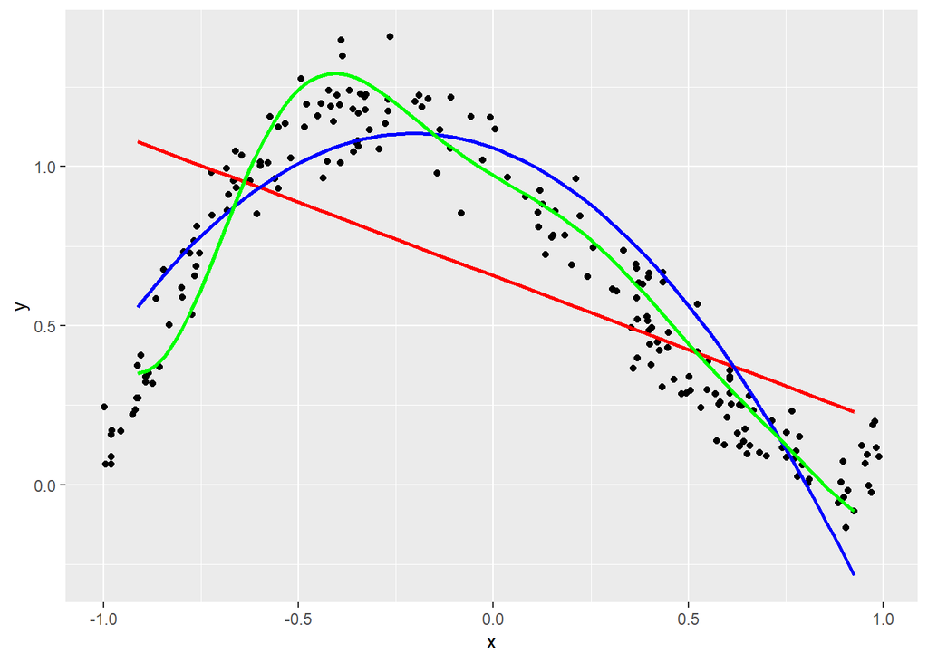

```r
ggplot() +
  geom_point(data=data_all,
             aes(x=x,y=y)) +
  geom_smooth(data=data_a,
              aes(x=x,y=y),
              method="lm",
              formula=y~poly(x,1),
              col="red",
              se=F) +
  geom_smooth(data=data_a,
              aes(x=x,y=y),
              method="lm",
              formula=y~poly(x,2),
              col="blue",
              se=F) +
  geom_smooth(data=data_a,
              aes(x=x,y=y),
              method="lm",
              formula=y~poly(x,10),
              col="green",
              se=F)
```

- What if we were to look at the results across all degrees?
- What if we were to have taken a different sample, of the same size, from the original data?
- What if we let the degree of the polynomial reach 19?

**Preventing Overfitting:**

- Cross-Validation: Use techniques like k-fold cross-validation to ensure the model generalizes well.
- Regularization: Add penalties for larger coefficients (e.g., Lasso or Ridge regression).
- Simpler Models: Use models that are appropriate for the complexity of the data.
- Pruning: In decision trees, prune branches that have little importance.
- Early Stopping: In iterative models like neural networks, stop training when performance on a validation set starts to degrade.
- *Watch out for upcoming sessions*